# CSE-221710309053-Hari Sarmishta

## Question-1:

### Read the dataset from the below path:

https://raw.githubusercontent.com/Mounika-Kajjam/Datasets/master/cities.csv

1. Check the data types and summary statistics of the dataset
2. Select random columns as Series and random columns as dataframe
3. Convert the data type of integer cols to float and float cols to integer
4. Visualize the missing values through heatmap
5. Dropt the duplicate values if found any
6. Get the row which has highest population
7. Calculate the mean of the population total grouped by States and sort the population total in ascending order and plot a horizontal bar chart for that.
8. Create a dataframe of five cities which have lowest population
9. Create a dataframe of five cities which have highest population
10. Concatenate the top five and bottom five cities based on the population

```python
import pandas as pd
import numpy as np
import matplotlib.pyplot as plt
import seaborn as sns
```

```python
df=pd.read_csv("cities.csv")
df
```

|  | name_of_city | state_code | state_name | dist_code | population_total | population_male | population_female | 0-6_population_total | 0-6_population_male | 0-6_population_female | ... | literates_female | sex_ratio | child_sex_ratio | effective_literacy_rate_total | effective_literacy_rate_male | effective_literacy_rate_female | location | total_graduates | male_graduates | female_graduates |
| --- | --- | --- | --- | --- | --- | --- | --- | --- | --- | --- | --- | --- | --- | --- | --- | --- | --- | --- | --- | --- | --- |
| 0 | Abohar | 3 | PUNJAB | 9 | 145238 | 76840 | 68398 | 15870 | 8587 | 7283 | ... | 44972 | 890 | 848 | 79.86 | 85.49 | 73.59 | 30.1452928,74.1993043 | 16287 | 8612 | 7675 |
| 1 | Achalpur | 27 | MAHARASHTRA | 7 | 112293 | 58256 | 54037 | 11810 | 6186 | 5624 | ... | 43086 | 928 | 909 | 91.99 | 94.77 | 89.00 | 21.257584,77.5086754 | 8863 | 5269 | 3594 |
| 2 | Adilabad | 28 | ANDHRA PRADESH | 1 | 117388 | 59232 | 58156 | 13103 | 6731 | 6372 | ... | 37660 | 982 | 947 | 80.51 | 88.18 | 72.73 | 19.0809075,79.560344 | 10565 | 6797 | 3768 |
| 3 | Adityapur | 20 | JHARKHAND | 24 | 173988 | 91495 | 82493 | 23042 | 12063 | 10979 | ... | 54515 | 902 | 910 | 83.46 | 89.98 | 76.23 | 22.7834741,86.1576889 | 19225 | 12189 | 7036 |
| 4 | Adoni | 28 | ANDHRA PRADESH | 21 | 166537 | 82743 | 83794 | 18406 | 9355 | 9051 | ... | 45089 | 1013 | 968 | 68.38 | 76.58 | 60.33 | 15.6322227,77.2728368 | 11902 | 7871 | 4031 |
| 5 | Agartala | 16 | TRIPURA | 1 | 399688 | 199616 | 200072 | 33635 | 17341 | 16294 | ... | 169109 | 1002 | 940 | 93.88 | 95.75 | 92.02 | 23.831457,91.2867777 | 52711 | 30215 | 22496 |
| 6 | Agra | 9 | UTTAR PRADESH | 15 | 1574542 | 849771 | 724771 | 186516 | 105279 | 81237 | ... | 376725 | 853 | 772 | 63.44 | 67.67 | 58.54 | 27.1766701,78.0080745 | 185813 | 106082 | 79731 |
| 7 | Ahmadabad | 24 | GUJARAT | 7 | 5570585 | 2935869 | 2634716 | 589076 | 317917 | 271159 | ... | 2004480 | 897 | 853 | 89.62 | 93.96 | 84.81 | 23.022505,72.5713621 | 769858 | 435267 | 334591 |
| 8 | Ahmadnagar | 27 | MAHARASHTRA | 26 | 350905 | 179755 | 171150 | 36712 | 19748 | 16964 | ... | 134649 | 952 | 859 | 91.49 | 95.51 | 87.33 | 19.0952075,74.7495916 | 51661 | 29832 | 21829 |
| 9 | Aizawl | 15 | MIZORAM | 3 | 291822 | 143803 | 148019 | 35147 | 17667 | 17480 | ... | 128332 | 1029 | 989 | 98.80 | 99.30 | 98.31 | 23.727107,92.7176389 | 26832 | 14900 | 11932 |
| 10 | Ajmer | 8 | RAJASTHAN | 21 | 542580 | 278786 | 263794 | 59437 | 31547 | 27890 | ... | 192327 | 946 | 884 | 87.53 | 93.26 | 81.53 | 26.4498954,74.6399163 | 77989 | 42454 | 35535 |
| 11 | Akbarpur | 9 | UTTAR PRADESH | 47 | 111594 | 57560 | 54034 | 14037 | 7247 | 6790 | ... | 32854 | 939 | 937 | 76.94 | 83.89 | 69.54 | 26.4407468,82.5537514 | 9745 | 5811 | 3934 |
| 12 | Akola | 27 | MAHARASHTRA | 5 | 427146 | 218184 | 208962 | 46500 | 24488 | 22012 | ... | 164093 | 958 | 899 | 91.34 | 94.78 | 87.77 | 20.7059345,77.0219019 | 49715 | 28812 | 20903 |
| 13 | Alandur | 33 | TAMIL NADU | 3 | 164162 | 82190 | 81972 | 14486 | 7336 | 7150 | ... | 69660 | 997 | 975 | 95.15 | 97.20 | 93.10 | 12.9974873,80.2006371 | 45971 | 25463 | 20508 |
| 14 | Alappuzha | 32 | KERALA | 11 | 174164 | 83888 | 90276 | 15434 | 7934 | 7500 | ... | 78815 | 1076 | 945 | 96.56 | 98.03 | 95.21 | 9.4980667,76.3388484 | 22263 | 9900 | 12363 |
| 15 | Aligarh | 9 | UTTAR PRADESH | 12 | 872575 | 463123 | 409452 | 113658 | 60620 | 53038 | ... | 230083 | 884 | 875 | 70.36 | 75.50 | 64.55 | 27.8973944,78.0880129 | 99341 | 55965 | 43376 |
| 16 | Allahabad | 9 | UTTAR PRADESH | 44 | 1117094 | 601363 | 515731 | 102556 | 54660 | 47896 | ... | 384409 | 858 | 876 | 86.50 | 90.21 | 82.17 | 25.4358011,81.846311 | 233129 | 138248 | 94881 |
| 17 | Alwar | 8 | RAJASTHAN | 6 | 315310 | 166900 | 148410 | 34576 | 18862 | 15714 | ... | 104897 | 889 | 833 | 86.78 | 93.72 | 79.05 | 27.5529907,76.6345735 | 58764 | 35297 | 23467 |
| 18 | Ambala | 6 | HARYANA | 2 | 196216 | 103533 | 92683 | 19645 | 10713 | 8932 | ... | 70776 | 895 | 834 | 88.23 | 91.58 | 84.51 | 30.3781788,76.7766974 | 34943 | 17809 | 17134 |
| 19 | Ambala Sadar | 6 | HARYANA | 2 | 104268 | 54241 | 50027 | 9646 | 5239 | 4407 | ... | 39792 | 922 | 841 | 87.97 | 88.66 | 87.22 | 30.3248708,76.8432663 | 20618 | 10689 | 9929 |
| 20 | Ambarnath | 27 | MAHARASHTRA | 21 | 254003 | 133006 | 120997 | 27465 | 14406 | 13059 | ... | 90434 | 910 | 906 | 89.04 | 93.82 | 83.78 | 19.1825167,73.1926023 | 26596 | 14444 | 12152 |
| 21 | Ambattur | 33 | TAMIL NADU | 1 | 478134 | 241181 | 236953 | 45216 | 23065 | 22151 | ... | 192505 | 982 | 960 | 92.69 | 95.71 | 89.62 | 13.1143167,80.1480551 | 97186 | 52224 | 44962 |
| 22 | Ambikapur | 22 | CHHATTISGARH | 2 | 114575 | 59673 | 54902 | 12995 | 6887 | 6108 | ... | 40640 | 920 | 887 | 88.20 | 92.73 | 83.29 | 23.1354921,83.1817856 | 20857 | 12369 | 8488 |
| 23 | Ambur | 33 | TAMIL NADU | 4 | 113856 | 56052 | 57804 | 12150 | 6216 | 5934 | ... | 42870 | 1031 | 955 | 86.83 | 91.18 | 82.65 | 12.7903613,78.7166084 | 7813 | 5076 | 2737 |
| 24 | Amravati | 27 | MAHARASHTRA | 7 | 646801 | 330544 | 316257 | 62497 | 32713 | 29784 | ... | 259078 | 957 | 910 | 93.03 | 95.52 | 90.44 | 20.9374238,77.7795513 | 91996 | 51456 | 40540 |
| 25 | Amreli | 24 | GUJARAT | 13 | 105980 | 55166 | 50814 | 9885 | 5386 | 4499 | ... | 39254 | 921 | 835 | 89.47 | 93.85 | 84.75 | 21.6031774,71.2220832 | 11305 | 6579 | 4726 |
| 26 | Amritsar | 3 | PUNJAB | 15 | 1132761 | 602754 | 530007 | 109540 | 60056 | 49484 | ... | 394465 | 879 | 824 | 85.27 | 88.09 | 82.09 | 31.6339793,74.8722642 | 140359 | 69241 | 71118 |
| 27 | Amroha | 9 | UTTAR PRADESH | 6 | 197135 | 102804 | 94331 | 26855 | 13799 | 13056 | ... | 48151 | 918 | 946 | 63.88 | 68.11 | 59.24 | 28.9043537,78.4673426 | 13879 | 7635 | 6244 |
| 28 | Anand | 24 | GUJARAT | 15 | 197351 | 102359 | 94992 | 19993 | 10631 | 9362 | ... | 77767 | 928 | 881 | 93.71 | 96.42 | 90.82 | 22.5645175,72.928871 | 29803 | 17331 | 12472 |
| 29 | Anantapur | 28 | ANDHRA PRADESH | 22 | 262340 | 131506 | 130834 | 23630 | 12409 | 11221 | ... | 90000 | 995 | 904 | 81.88 | 88.54 | 75.24 | 14.6818877,77.6005911 | 43700 | 27392 | 16308 |
| ... | ... | ... | ... | ... | ... | ... | ... | ... | ... | ... | ... | ... | ... | ... | ... | ... | ... | ... | ... | ... | ... |
| 463 | Tirunelveli | 33 | TAMIL NADU | 27 | 474838 | 234643 | 240195 | 43988 | 22511 | 21477 | ... | 190463 | 1024 | 954 | 90.98 | 94.99 | 87.08 | 8.7139126,77.7566523 | 59397 | 33536 | 25861 |
| 464 | Tirupati | 28 | ANDHRA PRADESH | 23 | 287035 | 145977 | 141058 | 24643 | 12869 | 11774 | ... | 106281 | 966 | 915 | 87.55 | 92.74 | 82.21 | 13.6287557,79.4191795 | 55454 | 34588 | 20866 |
| 465 | Tiruppur | 33 | TAMIL NADU | 32 | 444543 | 227469 | 217074 | 45091 | 23039 | 22052 | ... | 160710 | 954 | 957 | 87.67 | 92.69 | 82.41 | 11.1085242,77.3410656 | 33358 | 18431 | 14927 |
| 466 | Tiruvannamalai | 33 | TAMIL NADU | 5 | 144683 | 72351 | 72332 | 14530 | 7413 | 7117 | ... | 50671 | 1000 | 960 | 81.64 | 85.60 | 77.70 | 12.2252841,79.0746957 | 16502 | 9655 | 6847 |
| 467 | Tiruvottiyur | 33 | TAMIL NADU | 1 | 248059 | 124852 | 123207 | 24007 | 12185 | 11822 | ... | 94449 | 987 | 970 | 88.21 | 91.59 | 84.80 | 13.1691914,80.3045793 | 25781 | 13493 | 12288 |
| 468 | Titagarh | 19 | WEST BENGAL | 11 | 118426 | 63936 | 54490 | 10816 | 5729 | 5087 | ... | 36790 | 852 | 888 | 81.18 | 86.87 | 74.47 | 22.7382665,88.3737064 | 5643 | 3898 | 1745 |
| 469 | Tonk | 8 | RAJASTHAN | 22 | 165363 | 84927 | 80436 | 23122 | 12280 | 10842 | ... | 41649 | 947 | 883 | 69.47 | 78.70 | 59.85 | 26.1620402,75.7894716 | 11776 | 7537 | 4239 |
| 470 | Tumkur | 29 | KARNATAKA | 17 | 305821 | 155406 | 150415 | 29655 | 15233 | 14422 | ... | 113520 | 968 | 947 | 85.97 | 88.39 | 83.47 | 13.3709627,76.6412712 | 42163 | 25617 | 16546 |
| 471 | Udaipur | 8 | RAJASTHAN | 32 | 451735 | 234681 | 217054 | 47352 | 25338 | 22014 | ... | 166547 | 925 | 869 | 90.66 | 95.56 | 85.39 | 24.585445,73.712479 | 92090 | 51475 | 40615 |
| 472 | Udgir | 27 | MAHARASHTRA | 28 | 104063 | 54445 | 49618 | 13075 | 6933 | 6142 | ... | 34533 | 911 | 886 | 85.78 | 91.59 | 79.43 | 18.3942882,77.1126009 | 9924 | 6900 | 3024 |
| 473 | Udupi | 29 | KARNATAKA | 15 | 125350 | 62031 | 63319 | 10283 | 5364 | 4919 | ... | 53351 | 1021 | 917 | 93.89 | 96.51 | 91.35 | 13.3408807,74.7421427 | 22444 | 11795 | 10649 |
| 474 | Ujjain | 23 | MADHYA PRADESH | 18 | 515215 | 265291 | 249924 | 57630 | 30007 | 27623 | ... | 176989 | 942 | 921 | 85.55 | 91.16 | 79.62 | 23.1793013,75.7849097 | 72743 | 41616 | 31127 |
| 475 | Ulhasnagar | 27 | MAHARASHTRA | 21 | 506937 | 270373 | 236564 | 48513 | 25492 | 23021 | ... | 180984 | 875 | 903 | 89.21 | 93.10 | 84.75 | 19.2215115,73.1644628 | 43561 | 23087 | 20474 |
| 476 | Uluberia | 19 | WEST BENGAL | 15 | 222175 | 114144 | 108031 | 25187 | 12991 | 12196 | ... | 73616 | 946 | 939 | 81.13 | 85.23 | 76.82 | 22.4744363,88.1000377 | 11384 | 7234 | 4150 |
| 477 | Unnao | 9 | UTTAR PRADESH | 25 | 178681 | 94080 | 84601 | 18604 | 9949 | 8655 | ... | 60607 | 899 | 870 | 83.72 | 87.26 | 79.80 | 26.5393449,80.4878195 | 27220 | 15670 | 11550 |
| 478 | Uttarpara Kotrung | 19 | WEST BENGAL | 12 | 162386 | 82815 | 79571 | 11140 | 5815 | 5325 | ... | 65893 | 961 | 916 | 91.16 | 93.48 | 88.75 | 22.6768451,88.3385053 | 35773 | 20981 | 14792 |
| 479 | Vadodara | 24 | GUJARAT | 19 | 1666703 | 866701 | 800002 | 156480 | 84307 | 72173 | ... | 647672 | 923 | 856 | 92.37 | 95.51 | 88.99 | 22.3071588,73.1812187 | 279959 | 153236 | 126723 |
| 480 | Valsad | 24 | GUJARAT | 24 | 114987 | 58958 | 56029 | 9609 | 5119 | 4490 | ... | 46240 | 950 | 877 | 92.70 | 95.56 | 89.72 | 20.5992349,72.9342451 | 18980 | 10382 | 8598 |
| 481 | Varanasi | 9 | UTTAR PRADESH | 66 | 1201815 | 636860 | 564955 | 129180 | 68761 | 60419 | ... | 381572 | 887 | 879 | 80.12 | 84.11 | 75.63 | 25.3176452,82.9739144 | 172622 | 101440 | 71182 |
| 482 | Vasai Virar City | 27 | MAHARASHTRA | 21 | 1221233 | 649535 | 571698 | 137343 | 71716 | 65627 | ... | 439778 | 880 | 915 | 91.15 | 94.86 | 86.90 | 19.3919275,72.8397317 | 129954 | 70016 | 59938 |
| 483 | Vellore | 33 | TAMIL NADU | 4 | 185895 | 91464 | 94431 | 18363 | 9305 | 9058 | ... | 69871 | 1032 | 973 | 86.67 | 91.68 | 81.84 | 12.9165167,79.1324986 | 15592 | 8912 | 6680 |
| 484 | Veraval | 24 | GUJARAT | 12 | 153696 | 78161 | 75535 | 17107 | 9003 | 8104 | ... | 46666 | 966 | 900 | 78.00 | 86.58 | 69.21 | 20.9158979,70.3628516 | 10089 | 6246 | 3843 |
| 485 | Vidisha | 23 | MADHYA PRADESH | 26 | 155959 | 81424 | 74535 | 19360 | 10122 | 9238 | ... | 52876 | 915 | 913 | 86.88 | 92.29 | 80.98 | 23.5251102,77.8081363 | 22023 | 13177 | 8846 |
| 486 | Vijayawada | 28 | ANDHRA PRADESH | 16 | 1048240 | 524918 | 523322 | 92848 | 47582 | 45266 | ... | 377361 | 997 | 951 | 82.59 | 86.24 | 78.94 | 16.5061743,80.6480153 | 135425 | 81146 | 54279 |
| 487 | Visakhapatnam | 28 | ANDHRA PRADESH | 13 | 1730320 | 875199 | 855121 | 158924 | 81119 | 77805 | ... | 599937 | 977 | 959 | 82.66 | 88.02 | 77.18 | 17.6868,83.2185 | 250549 | 148824 | 101725 |
| 488 | Vizianagaram | 28 | ANDHRA PRADESH | 12 | 227533 | 111596 | 115937 | 20487 | 10495 | 9992 | ... | 80306 | 1039 | 952 | 81.85 | 88.18 | 75.80 | 18.1066576,83.3955506 | 30656 | 19173 | 11483 |
| 489 | Warangal | 28 | ANDHRA PRADESH | 9 | 620116 | 310400 | 309716 | 55392 | 28434 | 26958 | ... | 217136 | 998 | 948 | 84.16 | 91.54 | 76.79 | 17.9689008,79.5940544 | 109613 | 69507 | 40106 |
| 490 | Wardha | 27 | MAHARASHTRA | 8 | 105543 | 53241 | 52302 | 9754 | 5139 | 4615 | ... | 43339 | 982 | 898 | 94.05 | 97.19 | 90.88 | 20.745319,78.6021946 | 19363 | 10645 | 8718 |
| 491 | Yamunanagar | 6 | HARYANA | 3 | 216628 | 115404 | 101224 | 22905 | 12556 | 10349 | ... | 74255 | 877 | 824 | 85.91 | 89.61 | 81.71 | 30.1290485,77.2673901 | 29803 | 14349 | 15454 |
| 492 | Yavatmal | 27 | MAHARASHTRA | 14 | 116714 | 58717 | 57997 | 11081 | 5894 | 5187 | ... | 46561 | 988 | 880 | 91.81 | 95.45 | 88.17 | 20.3887937,78.1204073 | 13511 | 7397 | 6114 |

493 rows × 22 columns

## Check the data types and summary statistics of the dataset

```python
df.info()
```

```
<class 'pandas.core.frame.DataFrame'>
RangeIndex: 493 entries, 0 to 492
Data columns (total 22 columns):
name_of_city                      493 non-null object
state_code                        493 non-null int64
state_name                        493 non-null object
dist_code                         493 non-null int64
population_total                  493 non-null int64
population_male                   493 non-null int64
population_female                 493 non-null int64
0-6_population_total              493 non-null int64
0-6_population_male               493 non-null int64
0-6_population_female             493 non-null int64
literates_total                   493 non-null int64
literates_male                    493 non-null int64
literates_female                  493 non-null int64
sex_ratio                         493 non-null int64
child_sex_ratio                   493 non-null int64
effective_literacy_rate_total     493 non-null float64
effective_literacy_rate_male      493 non-null float64
effective_literacy_rate_female    493 non-null float64
location                          493 non-null object
total_graduates                   493 non-null int64
male_graduates                    493 non-null int64
female_graduates                  493 non-null int64
dtypes: float64(3), int64(16), object(3)
memory usage: 84.8+ KB
```

```python
df.describe()
```

|  | state_code | dist_code | population_total | population_male | population_female | 0-6_population_total | 0-6_population_male | 0-6_population_female | literates_total | literates_male | literates_female | sex_ratio | child_sex_ratio | effective_literacy_rate_total | effective_literacy_rate_male | effective_literacy_rate_female | total_graduates | male_graduates | female_graduates |
| --- | --- | --- | --- | --- | --- | --- | --- | --- | --- | --- | --- | --- | --- | --- | --- | --- | --- | --- | --- |
| count | 493.000000 | 493.000000 | 4.930000e+02 | 4.930000e+02 | 4.930000e+02 | 4.930000e+02 | 493.000000 | 493.000000 | 4.930000e+02 | 4.930000e+02 | 4.930000e+02 | 493.000000 | 493.000000 | 493.000000 | 493.000000 | 493.000000 | 4.930000e+02 | 4.930000e+02 | 4.930000e+02 |
| mean | 18.643002 | 16.782961 | 4.481124e+05 | 2.343468e+05 | 2.137656e+05 | 4.709285e+04 | 24849.527383 | 22243.320487 | 3.461527e+05 | 1.894384e+05 | 1.567143e+05 | 930.294118 | 902.332657 | 85.131460 | 89.920162 | 79.967181 | 6.620236e+04 | 3.771556e+04 | 2.848680e+04 |
| std | 9.297168 | 15.566131 | 1.033228e+06 | 5.487786e+05 | 4.848622e+05 | 1.050279e+05 | 55535.310272 | 49523.241379 | 8.220952e+05 | 4.534753e+05 | 3.690677e+05 | 55.849106 | 49.794689 | 6.186345 | 5.377492 | 7.577825 | 1.778187e+05 | 9.849574e+04 | 7.951556e+04 |
| min | 1.000000 | 1.000000 | 1.000360e+05 | 5.020100e+04 | 4.512600e+04 | 6.547000e+03 | 3406.000000 | 3107.000000 | 5.699800e+04 | 3.475100e+04 | 2.224700e+04 | 700.000000 | 762.000000 | 49.510000 | 52.270000 | 46.450000 | 2.532000e+03 | 1.703000e+03 | 8.290000e+02 |
| 25% | 9.000000 | 7.000000 | 1.261420e+05 | 6.638400e+04 | 6.041100e+04 | 1.363900e+04 | 7221.000000 | 6457.000000 | 9.768700e+04 | 5.357800e+04 | 4.391400e+04 | 890.000000 | 868.000000 | 81.750000 | 87.280000 | 75.800000 | 1.527700e+04 | 9.289000e+03 | 6.114000e+03 |
| 50% | 19.000000 | 13.000000 | 1.841330e+05 | 9.665500e+04 | 8.776800e+04 | 1.944000e+04 | 10342.000000 | 9172.000000 | 1.413290e+05 | 7.590600e+04 | 6.383600e+04 | 922.000000 | 903.000000 | 85.970000 | 91.180000 | 80.920000 | 2.395900e+04 | 1.404900e+04 | 9.558000e+03 |
| 75% | 27.000000 | 21.000000 | 3.490330e+05 | 1.750550e+05 | 1.700260e+05 | 3.794500e+04 | 19982.000000 | 17954.000000 | 2.679000e+05 | 1.455480e+05 | 1.235030e+05 | 971.000000 | 942.000000 | 89.330000 | 93.400000 | 85.400000 | 5.036700e+04 | 2.787200e+04 | 2.086600e+04 |
| max | 35.000000 | 99.000000 | 1.247845e+07 | 6.736815e+06 | 5.741632e+06 | 1.209275e+06 | 647938.000000 | 561337.000000 | 1.023759e+07 | 5.727774e+06 | 4.509812e+06 | 1093.000000 | 1185.000000 | 98.800000 | 99.300000 | 98.310000 | 2.221137e+06 | 1.210040e+06 | 1.011097e+06 |

## Select random columns as Series and random columns as dataframe

```python
df1=pd.DataFrame(df.sample(axis=1))
df1
```

|  | literates_female |
| --- | --- |
| 0 | 44972 |
| 1 | 43086 |
| 2 | 37660 |
| 3 | 54515 |
| 4 | 45089 |
| 5 | 169109 |
| 6 | 376725 |
| 7 | 2004480 |
| 8 | 134649 |
| 9 | 128332 |
| 10 | 192327 |
| 11 | 32854 |
| 12 | 164093 |
| 13 | 69660 |
| 14 | 78815 |
| 15 | 230083 |
| 16 | 384409 |
| 17 | 104897 |
| 18 | 70776 |
| 19 | 39792 |
| 20 | 90434 |
| 21 | 192505 |
| 22 | 40640 |
| 23 | 42870 |
| 24 | 259078 |
| 25 | 39254 |
| 26 | 394465 |
| 27 | 48151 |
| 28 | 77767 |
| 29 | 90000 |
| ... | ... |
| 463 | 190463 |
| 464 | 106281 |
| 465 | 160710 |
| 466 | 50671 |
| 467 | 94449 |
| 468 | 36790 |
| 469 | 41649 |
| 470 | 113520 |
| 471 | 166547 |
| 472 | 34533 |
| 473 | 53351 |
| 474 | 176989 |
| 475 | 180984 |
| 476 | 73616 |
| 477 | 60607 |
| 478 | 65893 |
| 479 | 647672 |
| 480 | 46240 |
| 481 | 381572 |
| 482 | 439778 |
| 483 | 69871 |
| 484 | 46666 |
| 485 | 52876 |
| 486 | 377361 |
| 487 | 599937 |
| 488 | 80306 |
| 489 | 217136 |
| 490 | 43339 |
| 491 | 74255 |
| 492 | 46561 |

493 rows × 1 columns

```python
s1=pd.DataFrame(df.sample(axis=1))
s1
```

|  | literates_total |
| --- | --- |
| 0 | 103319 |
| 1 | 92433 |
| 2 | 83955 |
| 3 | 125985 |
| 4 | 101292 |
| 5 | 343633 |
| 6 | 880530 |
| 7 | 4464303 |
| 8 | 287468 |
| 9 | 253588 |
| 10 | 422913 |
| 11 | 75062 |
| 12 | 347687 |
| 13 | 142415 |
| 14 | 153269 |
| 15 | 533969 |
| 16 | 877590 |
| 17 | 243634 |
| 18 | 155780 |
| 19 | 83236 |
| 20 | 201707 |
| 21 | 401253 |
| 22 | 89590 |
| 23 | 88309 |
| 24 | 543568 |
| 25 | 85975 |
| 26 | 872527 |
| 27 | 108772 |
| 28 | 166211 |
| 29 | 195452 |
| ... | ... |
| 463 | 391972 |
| 464 | 229730 |
| 465 | 350206 |
| 466 | 106256 |
| 467 | 197646 |
| 468 | 87356 |
| 469 | 98819 |
| 470 | 237424 |
| 471 | 366598 |
| 472 | 78051 |
| 473 | 108041 |
| 474 | 391470 |
| 475 | 408959 |
| 476 | 159826 |
| 477 | 134018 |
| 478 | 137869 |
| 479 | 1394952 |
| 480 | 97687 |
| 481 | 859379 |
| 482 | 987916 |
| 483 | 145192 |
| 484 | 106540 |
| 485 | 118678 |
| 486 | 789038 |
| 487 | 1298896 |
| 488 | 169461 |
| 489 | 475247 |
| 490 | 90091 |
| 491 | 166419 |
| 492 | 96980 |

493 rows × 1 columns

## Convert the data type of integer cols to float and float cols to integer

```python
df_int = df.select_dtypes(include='int64')
df_int=df_int.astype(float)
df_int
```

|  | state_code | dist_code | population_total | population_male | population_female | 0-6_population_total | 0-6_population_male | 0-6_population_female | literates_total | literates_male | literates_female | sex_ratio | child_sex_ratio | total_graduates | male_graduates | female_graduates |
| --- | --- | --- | --- | --- | --- | --- | --- | --- | --- | --- | --- | --- | --- | --- | --- | --- |
| 0 | 3.0 | 9.0 | 145238.0 | 76840.0 | 68398.0 | 15870.0 | 8587.0 | 7283.0 | 103319.0 | 58347.0 | 44972.0 | 890.0 | 848.0 | 16287.0 | 8612.0 | 7675.0 |
| 1 | 27.0 | 7.0 | 112293.0 | 58256.0 | 54037.0 | 11810.0 | 6186.0 | 5624.0 | 92433.0 | 49347.0 | 43086.0 | 928.0 | 909.0 | 8863.0 | 5269.0 | 3594.0 |
| 2 | 28.0 | 1.0 | 117388.0 | 59232.0 | 58156.0 | 13103.0 | 6731.0 | 6372.0 | 83955.0 | 46295.0 | 37660.0 | 982.0 | 947.0 | 10565.0 | 6797.0 | 3768.0 |
| 3 | 20.0 | 24.0 | 173988.0 | 91495.0 | 82493.0 | 23042.0 | 12063.0 | 10979.0 | 125985.0 | 71470.0 | 54515.0 | 902.0 | 910.0 | 19225.0 | 12189.0 | 7036.0 |
| 4 | 28.0 | 21.0 | 166537.0 | 82743.0 | 83794.0 | 18406.0 | 9355.0 | 9051.0 | 101292.0 | 56203.0 | 45089.0 | 1013.0 | 968.0 | 11902.0 | 7871.0 | 4031.0 |
| 5 | 16.0 | 1.0 | 399688.0 | 199616.0 | 200072.0 | 33635.0 | 17341.0 | 16294.0 | 343633.0 | 174524.0 | 169109.0 | 1002.0 | 940.0 | 52711.0 | 30215.0 | 22496.0 |
| 6 | 9.0 | 15.0 | 1574542.0 | 849771.0 | 724771.0 | 186516.0 | 105279.0 | 81237.0 | 880530.0 | 503805.0 | 376725.0 | 853.0 | 772.0 | 185813.0 | 106082.0 | 79731.0 |
| 7 | 24.0 | 7.0 | 5570585.0 | 2935869.0 | 2634716.0 | 589076.0 | 317917.0 | 271159.0 | 4464303.0 | 2459823.0 | 2004480.0 | 897.0 | 853.0 | 769858.0 | 435267.0 | 334591.0 |
| 8 | 27.0 | 26.0 | 350905.0 | 179755.0 | 171150.0 | 36712.0 | 19748.0 | 16964.0 | 287468.0 | 152819.0 | 134649.0 | 952.0 | 859.0 | 51661.0 | 29832.0 | 21829.0 |
| 9 | 15.0 | 3.0 | 291822.0 | 143803.0 | 148019.0 | 35147.0 | 17667.0 | 17480.0 | 253588.0 | 125256.0 | 128332.0 | 1029.0 | 989.0 | 26832.0 | 14900.0 | 11932.0 |
| 10 | 8.0 | 21.0 | 542580.0 | 278786.0 | 263794.0 | 59437.0 | 31547.0 | 27890.0 | 422913.0 | 230586.0 | 192327.0 | 946.0 | 884.0 | 77989.0 | 42454.0 | 35535.0 |
| 11 | 9.0 | 47.0 | 111594.0 | 57560.0 | 54034.0 | 14037.0 | 7247.0 | 6790.0 | 75062.0 | 42208.0 | 32854.0 | 939.0 | 937.0 | 9745.0 | 5811.0 | 3934.0 |
| 12 | 27.0 | 5.0 | 427146.0 | 218184.0 | 208962.0 | 46500.0 | 24488.0 | 22012.0 | 347687.0 | 183594.0 | 164093.0 | 958.0 | 899.0 | 49715.0 | 28812.0 | 20903.0 |
| 13 | 33.0 | 3.0 | 164162.0 | 82190.0 | 81972.0 | 14486.0 | 7336.0 | 7150.0 | 142415.0 | 72755.0 | 69660.0 | 997.0 | 975.0 | 45971.0 | 25463.0 | 20508.0 |
| 14 | 32.0 | 11.0 | 174164.0 | 83888.0 | 90276.0 | 15434.0 | 7934.0 | 7500.0 | 153269.0 | 74454.0 | 78815.0 | 1076.0 | 945.0 | 22263.0 | 9900.0 | 12363.0 |
| 15 | 9.0 | 12.0 | 872575.0 | 463123.0 | 409452.0 | 113658.0 | 60620.0 | 53038.0 | 533969.0 | 303886.0 | 230083.0 | 884.0 | 875.0 | 99341.0 | 55965.0 | 43376.0 |
| 16 | 9.0 | 44.0 | 1117094.0 | 601363.0 | 515731.0 | 102556.0 | 54660.0 | 47896.0 | 877590.0 | 493181.0 | 384409.0 | 858.0 | 876.0 | 233129.0 | 138248.0 | 94881.0 |
| 17 | 8.0 | 6.0 | 315310.0 | 166900.0 | 148410.0 | 34576.0 | 18862.0 | 15714.0 | 243634.0 | 138737.0 | 104897.0 | 889.0 | 833.0 | 58764.0 | 35297.0 | 23467.0 |
| 18 | 6.0 | 2.0 | 196216.0 | 103533.0 | 92683.0 | 19645.0 | 10713.0 | 8932.0 | 155780.0 | 85004.0 | 70776.0 | 895.0 | 834.0 | 34943.0 | 17809.0 | 17134.0 |
| 19 | 6.0 | 2.0 | 104268.0 | 54241.0 | 50027.0 | 9646.0 | 5239.0 | 4407.0 | 83236.0 | 43444.0 | 39792.0 | 922.0 | 841.0 | 20618.0 | 10689.0 | 9929.0 |
| 20 | 27.0 | 21.0 | 254003.0 | 133006.0 | 120997.0 | 27465.0 | 14406.0 | 13059.0 | 201707.0 | 111273.0 | 90434.0 | 910.0 | 906.0 | 26596.0 | 14444.0 | 12152.0 |
| 21 | 33.0 | 1.0 | 478134.0 | 241181.0 | 236953.0 | 45216.0 | 23065.0 | 22151.0 | 401253.0 | 208748.0 | 192505.0 | 982.0 | 960.0 | 97186.0 | 52224.0 | 44962.0 |
| 22 | 22.0 | 2.0 | 114575.0 | 59673.0 | 54902.0 | 12995.0 | 6887.0 | 6108.0 | 89590.0 | 48950.0 | 40640.0 | 920.0 | 887.0 | 20857.0 | 12369.0 | 8488.0 |
| 23 | 33.0 | 4.0 | 113856.0 | 56052.0 | 57804.0 | 12150.0 | 6216.0 | 5934.0 | 88309.0 | 45439.0 | 42870.0 | 1031.0 | 955.0 | 7813.0 | 5076.0 | 2737.0 |
| 24 | 27.0 | 7.0 | 646801.0 | 330544.0 | 316257.0 | 62497.0 | 32713.0 | 29784.0 | 543568.0 | 284490.0 | 259078.0 | 957.0 | 910.0 | 91996.0 | 51456.0 | 40540.0 |
| 25 | 24.0 | 13.0 | 105980.0 | 55166.0 | 50814.0 | 9885.0 | 5386.0 | 4499.0 | 85975.0 | 46721.0 | 39254.0 | 921.0 | 835.0 | 11305.0 | 6579.0 | 4726.0 |
| 26 | 3.0 | 15.0 | 1132761.0 | 602754.0 | 530007.0 | 109540.0 | 60056.0 | 49484.0 | 872527.0 | 478062.0 | 394465.0 | 879.0 | 824.0 | 140359.0 | 69241.0 | 71118.0 |
| 27 | 9.0 | 6.0 | 197135.0 | 102804.0 | 94331.0 | 26855.0 | 13799.0 | 13056.0 | 108772.0 | 60621.0 | 48151.0 | 918.0 | 946.0 | 13879.0 | 7635.0 | 6244.0 |
| 28 | 24.0 | 15.0 | 197351.0 | 102359.0 | 94992.0 | 19993.0 | 10631.0 | 9362.0 | 166211.0 | 88444.0 | 77767.0 | 928.0 | 881.0 | 29803.0 | 17331.0 | 12472.0 |
| 29 | 28.0 | 22.0 | 262340.0 | 131506.0 | 130834.0 | 23630.0 | 12409.0 | 11221.0 | 195452.0 | 105452.0 | 90000.0 | 995.0 | 904.0 | 43700.0 | 27392.0 | 16308.0 |
| ... | ... | ... | ... | ... | ... | ... | ... | ... | ... | ... | ... | ... | ... | ... | ... | ... |
| 463 | 33.0 | 27.0 | 474838.0 | 234643.0 | 240195.0 | 43988.0 | 22511.0 | 21477.0 | 391972.0 | 201509.0 | 190463.0 | 1024.0 | 954.0 | 59397.0 | 33536.0 | 25861.0 |
| 464 | 28.0 | 23.0 | 287035.0 | 145977.0 | 141058.0 | 24643.0 | 12869.0 | 11774.0 | 229730.0 | 123449.0 | 106281.0 | 966.0 | 915.0 | 55454.0 | 34588.0 | 20866.0 |
| 465 | 33.0 | 32.0 | 444543.0 | 227469.0 | 217074.0 | 45091.0 | 23039.0 | 22052.0 | 350206.0 | 189496.0 | 160710.0 | 954.0 | 957.0 | 33358.0 | 18431.0 | 14927.0 |
| 466 | 33.0 | 5.0 | 144683.0 | 72351.0 | 72332.0 | 14530.0 | 7413.0 | 7117.0 | 106256.0 | 55585.0 | 50671.0 | 1000.0 | 960.0 | 16502.0 | 9655.0 | 6847.0 |
| 467 | 33.0 | 1.0 | 248059.0 | 124852.0 | 123207.0 | 24007.0 | 12185.0 | 11822.0 | 197646.0 | 103197.0 | 94449.0 | 987.0 | 970.0 | 25781.0 | 13493.0 | 12288.0 |
| 468 | 19.0 | 11.0 | 118426.0 | 63936.0 | 54490.0 | 10816.0 | 5729.0 | 5087.0 | 87356.0 | 50566.0 | 36790.0 | 852.0 | 888.0 | 5643.0 | 3898.0 | 1745.0 |
| 469 | 8.0 | 22.0 | 165363.0 | 84927.0 | 80436.0 | 23122.0 | 12280.0 | 10842.0 | 98819.0 | 57170.0 | 41649.0 | 947.0 | 883.0 | 11776.0 | 7537.0 | 4239.0 |
| 470 | 29.0 | 17.0 | 305821.0 | 155406.0 | 150415.0 | 29655.0 | 15233.0 | 14422.0 | 237424.0 | 123904.0 | 113520.0 | 968.0 | 947.0 | 42163.0 | 25617.0 | 16546.0 |
| 471 | 8.0 | 32.0 | 451735.0 | 234681.0 | 217054.0 | 47352.0 | 25338.0 | 22014.0 | 366598.0 | 200051.0 | 166547.0 | 925.0 | 869.0 | 92090.0 | 51475.0 | 40615.0 |
| 472 | 27.0 | 28.0 | 104063.0 | 54445.0 | 49618.0 | 13075.0 | 6933.0 | 6142.0 | 78051.0 | 43518.0 | 34533.0 | 911.0 | 886.0 | 9924.0 | 6900.0 | 3024.0 |
| 473 | 29.0 | 15.0 | 125350.0 | 62031.0 | 63319.0 | 10283.0 | 5364.0 | 4919.0 | 108041.0 | 54690.0 | 53351.0 | 1021.0 | 917.0 | 22444.0 | 11795.0 | 10649.0 |
| 474 | 23.0 | 18.0 | 515215.0 | 265291.0 | 249924.0 | 57630.0 | 30007.0 | 27623.0 | 391470.0 | 214481.0 | 176989.0 | 942.0 | 921.0 | 72743.0 | 41616.0 | 31127.0 |
| 475 | 27.0 | 21.0 | 506937.0 | 270373.0 | 236564.0 | 48513.0 | 25492.0 | 23021.0 | 408959.0 | 227975.0 | 180984.0 | 875.0 | 903.0 | 43561.0 | 23087.0 | 20474.0 |
| 476 | 19.0 | 15.0 | 222175.0 | 114144.0 | 108031.0 | 25187.0 | 12991.0 | 12196.0 | 159826.0 | 86210.0 | 73616.0 | 946.0 | 939.0 | 11384.0 | 7234.0 | 4150.0 |
| 477 | 9.0 | 25.0 | 178681.0 | 94080.0 | 84601.0 | 18604.0 | 9949.0 | 8655.0 | 134018.0 | 73411.0 | 60607.0 | 899.0 | 870.0 | 27220.0 | 15670.0 | 11550.0 |
| 478 | 19.0 | 12.0 | 162386.0 | 82815.0 | 79571.0 | 11140.0 | 5815.0 | 5325.0 | 137869.0 | 71976.0 | 65893.0 | 961.0 | 916.0 | 35773.0 | 20981.0 | 14792.0 |
| 479 | 24.0 | 19.0 | 1666703.0 | 866701.0 | 800002.0 | 156480.0 | 84307.0 | 72173.0 | 1394952.0 | 747280.0 | 647672.0 | 923.0 | 856.0 | 279959.0 | 153236.0 | 126723.0 |
| 480 | 24.0 | 24.0 | 114987.0 | 58958.0 | 56029.0 | 9609.0 | 5119.0 | 4490.0 | 97687.0 | 51447.0 | 46240.0 | 950.0 | 877.0 | 18980.0 | 10382.0 | 8598.0 |
| 481 | 9.0 | 66.0 | 1201815.0 | 636860.0 | 564955.0 | 129180.0 | 68761.0 | 60419.0 | 859379.0 | 477807.0 | 381572.0 | 887.0 | 879.0 | 172622.0 | 101440.0 | 71182.0 |
| 482 | 27.0 | 21.0 | 1221233.0 | 649535.0 | 571698.0 | 137343.0 | 71716.0 | 65627.0 | 987916.0 | 548138.0 | 439778.0 | 880.0 | 915.0 | 129954.0 | 70016.0 | 59938.0 |
| 483 | 33.0 | 4.0 | 185895.0 | 91464.0 | 94431.0 | 18363.0 | 9305.0 | 9058.0 | 145192.0 | 75321.0 | 69871.0 | 1032.0 | 973.0 | 15592.0 | 8912.0 | 6680.0 |
| 484 | 24.0 | 12.0 | 153696.0 | 78161.0 | 75535.0 | 17107.0 | 9003.0 | 8104.0 | 106540.0 | 59874.0 | 46666.0 | 966.0 | 900.0 | 10089.0 | 6246.0 | 3843.0 |
| 485 | 23.0 | 26.0 | 155959.0 | 81424.0 | 74535.0 | 19360.0 | 10122.0 | 9238.0 | 118678.0 | 65802.0 | 52876.0 | 915.0 | 913.0 | 22023.0 | 13177.0 | 8846.0 |
| 486 | 28.0 | 16.0 | 1048240.0 | 524918.0 | 523322.0 | 92848.0 | 47582.0 | 45266.0 | 789038.0 | 411677.0 | 377361.0 | 997.0 | 951.0 | 135425.0 | 81146.0 | 54279.0 |
| 487 | 28.0 | 13.0 | 1730320.0 | 875199.0 | 855121.0 | 158924.0 | 81119.0 | 77805.0 | 1298896.0 | 698959.0 | 599937.0 | 977.0 | 959.0 | 250549.0 | 148824.0 | 101725.0 |
| 488 | 28.0 | 12.0 | 227533.0 | 111596.0 | 115937.0 | 20487.0 | 10495.0 | 9992.0 | 169461.0 | 89155.0 | 80306.0 | 1039.0 | 952.0 | 30656.0 | 19173.0 | 11483.0 |
| 489 | 28.0 | 9.0 | 620116.0 | 310400.0 | 309716.0 | 55392.0 | 28434.0 | 26958.0 | 475247.0 | 258111.0 | 217136.0 | 998.0 | 948.0 | 109613.0 | 69507.0 | 40106.0 |
| 490 | 27.0 | 8.0 | 105543.0 | 53241.0 | 52302.0 | 9754.0 | 5139.0 | 4615.0 | 90091.0 | 46752.0 | 43339.0 | 982.0 | 898.0 | 19363.0 | 10645.0 | 8718.0 |
| 491 | 6.0 | 3.0 | 216628.0 | 115404.0 | 101224.0 | 22905.0 | 12556.0 | 10349.0 | 166419.0 | 92164.0 | 74255.0 | 877.0 | 824.0 | 29803.0 | 14349.0 | 15454.0 |
| 492 | 27.0 | 14.0 | 116714.0 | 58717.0 | 57997.0 | 11081.0 | 5894.0 | 5187.0 | 96980.0 | 50419.0 | 46561.0 | 988.0 | 880.0 | 13511.0 | 7397.0 | 6114.0 |

493 rows × 16 columns

```python
df_float=df.select_dtypes(include='float64')
df_float=df_float.astype(int)
df_float
```

|  | effective_literacy_rate_total | effective_literacy_rate_male | effective_literacy_rate_female |
| --- | --- | --- | --- |
| 0 | 79 | 85 | 73 |
| 1 | 91 | 94 | 89 |
| 2 | 80 | 88 | 72 |
| 3 | 83 | 89 | 76 |
| 4 | 68 | 76 | 60 |
| 5 | 93 | 95 | 92 |
| 6 | 63 | 67 | 58 |
| 7 | 89 | 93 | 84 |
| 8 | 91 | 95 | 87 |
| 9 | 98 | 99 | 98 |
| 10 | 87 | 93 | 81 |
| 11 | 76 | 83 | 69 |
| 12 | 91 | 94 | 87 |
| 13 | 95 | 97 | 93 |
| 14 | 96 | 98 | 95 |
| 15 | 70 | 75 | 64 |
| 16 | 86 | 90 | 82 |
| 17 | 86 | 93 | 79 |
| 18 | 88 | 91 | 84 |
| 19 | 87 | 88 | 87 |
| 20 | 89 | 93 | 83 |
| 21 | 92 | 95 | 89 |
| 22 | 88 | 92 | 83 |
| 23 | 86 | 91 | 82 |
| 24 | 93 | 95 | 90 |
| 25 | 89 | 93 | 84 |
| 26 | 85 | 88 | 82 |
| 27 | 63 | 68 | 59 |
| 28 | 93 | 96 | 90 |
| 29 | 81 | 88 | 75 |
| ... | ... | ... | ... |
| 463 | 90 | 94 | 87 |
| 464 | 87 | 92 | 82 |
| 465 | 87 | 92 | 82 |
| 466 | 81 | 85 | 77 |
| 467 | 88 | 91 | 84 |
| 468 | 81 | 86 | 74 |
| 469 | 69 | 78 | 59 |
| 470 | 85 | 88 | 83 |
| 471 | 90 | 95 | 85 |
| 472 | 85 | 91 | 79 |
| 473 | 93 | 96 | 91 |
| 474 | 85 | 91 | 79 |
| 475 | 89 | 93 | 84 |
| 476 | 81 | 85 | 76 |
| 477 | 83 | 87 | 79 |
| 478 | 91 | 93 | 88 |
| 479 | 92 | 95 | 88 |
| 480 | 92 | 95 | 89 |
| 481 | 80 | 84 | 75 |
| 482 | 91 | 94 | 86 |
| 483 | 86 | 91 | 81 |
| 484 | 78 | 86 | 69 |
| 485 | 86 | 92 | 80 |
| 486 | 82 | 86 | 78 |
| 487 | 82 | 88 | 77 |
| 488 | 81 | 88 | 75 |
| 489 | 84 | 91 | 76 |
| 490 | 94 | 97 | 90 |
| 491 | 85 | 89 | 81 |
| 492 | 91 | 95 | 88 |

493 rows × 3 columns

## Visualize the missing values through heatmap

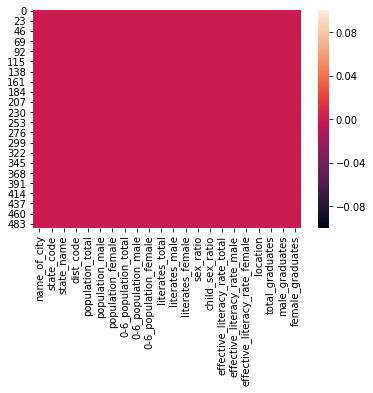

```python
sns.heatmap(df.isnull())
```

## Dropt the duplicate values if found any

```python
df1=pd.DataFrame(df)
for i in df1.columns:
    df1.drop_duplicates(i,inplace=True)
df1
```

|  | name_of_city | state_code | state_name | dist_code | population_total | population_male | population_female | 0-6_population_total | 0-6_population_male | 0-6_population_female | ... | literates_female | sex_ratio | child_sex_ratio | effective_literacy_rate_total | effective_literacy_rate_male | effective_literacy_rate_female | location | total_graduates | male_graduates | female_graduates |
| --- | --- | --- | --- | --- | --- | --- | --- | --- | --- | --- | --- | --- | --- | --- | --- | --- | --- | --- | --- | --- | --- |
| 0 | Abohar | 3 | PUNJAB | 9 | 145238 | 76840 | 68398 | 15870 | 8587 | 7283 | ... | 44972 | 890 | 848 | 79.86 | 85.49 | 73.59 | 30.1452928,74.1993043 | 16287 | 8612 | 7675 |
| 1 | Achalpur | 27 | MAHARASHTRA | 7 | 112293 | 58256 | 54037 | 11810 | 6186 | 5624 | ... | 43086 | 928 | 909 | 91.99 | 94.77 | 89.00 | 21.257584,77.5086754 | 8863 | 5269 | 3594 |
| 2 | Adilabad | 28 | ANDHRA PRADESH | 1 | 117388 | 59232 | 58156 | 13103 | 6731 | 6372 | ... | 37660 | 982 | 947 | 80.51 | 88.18 | 72.73 | 19.0809075,79.560344 | 10565 | 6797 | 3768 |
| 3 | Adityapur | 20 | JHARKHAND | 24 | 173988 | 91495 | 82493 | 23042 | 12063 | 10979 | ... | 54515 | 902 | 910 | 83.46 | 89.98 | 76.23 | 22.7834741,86.1576889 | 19225 | 12189 | 7036 |
| 6 | Agra | 9 | UTTAR PRADESH | 15 | 1574542 | 849771 | 724771 | 186516 | 105279 | 81237 | ... | 376725 | 853 | 772 | 63.44 | 67.67 | 58.54 | 27.1766701,78.0080745 | 185813 | 106082 | 79731 |
| 9 | Aizawl | 15 | MIZORAM | 3 | 291822 | 143803 | 148019 | 35147 | 17667 | 17480 | ... | 128332 | 1029 | 989 | 98.80 | 99.30 | 98.31 | 23.727107,92.7176389 | 26832 | 14900 | 11932 |
| 10 | Ajmer | 8 | RAJASTHAN | 21 | 542580 | 278786 | 263794 | 59437 | 31547 | 27890 | ... | 192327 | 946 | 884 | 87.53 | 93.26 | 81.53 | 26.4498954,74.6399163 | 77989 | 42454 | 35535 |
| 14 | Alappuzha | 32 | KERALA | 11 | 174164 | 83888 | 90276 | 15434 | 7934 | 7500 | ... | 78815 | 1076 | 945 | 96.56 | 98.03 | 95.21 | 9.4980667,76.3388484 | 22263 | 9900 | 12363 |
| 18 | Ambala | 6 | HARYANA | 2 | 196216 | 103533 | 92683 | 19645 | 10713 | 8932 | ... | 70776 | 895 | 834 | 88.23 | 91.58 | 84.51 | 30.3781788,76.7766974 | 34943 | 17809 | 17134 |
| 30 | Anantnag | 1 | JAMMU & KASHMIR | 14 | 108505 | 56030 | 52475 | 18056 | 9633 | 8423 | ... | 31817 | 937 | 874 | 78.95 | 85.33 | 72.23 | 33.7311255,75.1487007 | 12666 | 7291 | 5375 |
| 31 | Arrah | 10 | BIHAR | 29 | 261099 | 139319 | 121780 | 34419 | 18356 | 16063 | ... | 81258 | 874 | 875 | 83.41 | 89.14 | 76.86 | 25.5560443,84.6603307 | 35354 | 25045 | 10309 |
| 45 | Baleshwar Town | 21 | ORISSA | 8 | 118202 | 60308 | 57894 | 11115 | 5685 | 5430 | ... | 44712 | 960 | 955 | 88.79 | 92.22 | 85.22 | 21.4869337,86.9246005 | 23170 | 14071 | 9099 |
| 74 | Betul | 23 | MADHYA PRADESH | 30 | 103341 | 52902 | 50439 | 11005 | 5772 | 5233 | ... | 38927 | 953 | 907 | 90.27 | 94.27 | 86.11 | 21.9108031,77.9011842 | 17125 | 9918 | 7207 |
| 139 | Dehradun | 5 | UTTARAKHAND | 5 | 578420 | 303411 | 275009 | 59180 | 31600 | 27580 | ... | 211959 | 906 | 873 | 89.32 | 92.65 | 85.66 | 30.3164945,78.0321918 | 136036 | 70607 | 65429 |
| 220 | Imphal | 14 | MANIPUR | 99 | 264986 | 128931 | 136055 | 25877 | 13347 | 12530 | ... | 108452 | 1055 | 939 | 91.70 | 95.87 | 87.80 | 24.8170111,93.9368439 | 63915 | 33950 | 29965 |
| 430 | Shillong | 17 | MEGHALAYA | 6 | 143007 | 70028 | 72979 | 13792 | 7120 | 6672 | ... | 59893 | 1042 | 937 | 92.34 | 94.46 | 90.33 | 25.5714,91.8848 | 25113 | 12466 | 12647 |

16 rows × 22 columns

## Get the row which has highest population

```python
df[df.population_total==max(df['population_total'])]
```

|  | name_of_city | state_code | state_name | dist_code | population_total | population_male | population_female | 0-6_population_total | 0-6_population_male | 0-6_population_female | ... | literates_female | sex_ratio | child_sex_ratio | effective_literacy_rate_total | effective_literacy_rate_male | effective_literacy_rate_female | location | total_graduates | male_graduates | female_graduates |
| --- | --- | --- | --- | --- | --- | --- | --- | --- | --- | --- | --- | --- | --- | --- | --- | --- | --- | --- | --- | --- | --- |
| 185 | Greater Mumbai | 27 | MAHARASHTRA | 99 | 12478447 | 6736815 | 5741632 | 1139146 | 599007 | 540139 | ... | 4509812 | 852 | 902 | 90.28 | 93.32 | 86.7 | 19.0760,72.8777 | 1802371 | 964964 | 837407 |

1 rows × 22 columns

## Calculate the mean of the population total grouped by States and sort the population total in ascending order and plot a horizontal bar chart for that

```python
df2=df.groupby(['state_name'])['population_total'].mean()
df2=pd.DataFrame(df2)
df2.sort_values(by='population_total')
```

| state_name | population_total |
| --- | --- |
| ANDAMAN & NICOBAR ISLANDS | 100608.000000 |
| NAGALAND | 123777.000000 |
| MEGHALAYA | 143007.000000 |
| HIMACHAL PRADESH | 169758.000000 |
| UTTARAKHAND | 223399.500000 |
| BIHAR | 258250.615385 |
| MANIPUR | 264986.000000 |
| PUDUCHERRY | 270900.500000 |
| MIZORAM | 291822.000000 |
| WEST BENGAL | 296123.098361 |
| HARYANA | 297611.150000 |
| ORISSA | 300323.400000 |
| MADHYA PRADESH | 344471.593750 |
| ASSAM | 347788.500000 |
| CHHATTISGARH | 348657.555556 |
| RAJASTHAN | 360104.000000 |
| PUNJAB | 363867.250000 |
| KERALA | 393710.428571 |
| TRIPURA | 399688.000000 |
| UTTAR PRADESH | 401633.730159 |
| JHARKHAND | 427825.900000 |
| ANDHRA PRADESH | 432657.500000 |
| TAMIL NADU | 433731.093750 |
| JAMMU & KASHMIR | 601662.333333 |
| KARNATAKA | 607688.307692 |
| GUJARAT | 615001.689655 |
| MAHARASHTRA | 877258.976744 |
| NCT OF DELHI | 898799.800000 |
| CHANDIGARH | 960787.000000 |

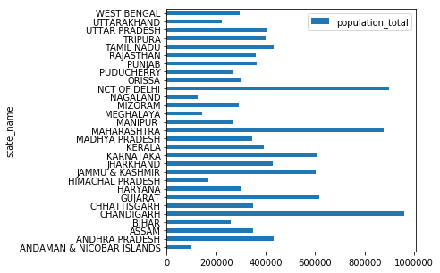

```python
df2.plot.barh(figsize=(5,5))
```

```python
df1=df.sort_values(by='population_total').head()
df1
```

|  | name_of_city | state_code | state_name | dist_code | population_total | population_male | population_female | 0-6_population_total | 0-6_population_male | 0-6_population_female | ... | literates_female | sex_ratio | child_sex_ratio | effective_literacy_rate_total | effective_literacy_rate_male | effective_literacy_rate_female | location | total_graduates | male_graduates | female_graduates |
| --- | --- | --- | --- | --- | --- | --- | --- | --- | --- | --- | --- | --- | --- | --- | --- | --- | --- | --- | --- | --- | --- |
| 332 | Nagda | 23 | MADHYA PRADESH | 18 | 100036 | 51410 | 48626 | 11053 | 5840 | 5213 | ... | 31853 | 946 | 893 | 81.61 | 89.46 | 73.37 | 23.4454599,75.4169918 | 9844 | 5707 | 4137 |
| 53 | Banswara | 8 | RAJASTHAN | 27 | 100128 | 51240 | 48888 | 12244 | 6602 | 5642 | ... | 35034 | 954 | 855 | 86.98 | 92.76 | 81.01 | 23.5461394,74.4349761 | 13852 | 7837 | 6015 |
| 211 | Hinganghat | 27 | MAHARASHTRA | 8 | 100416 | 51881 | 48535 | 9681 | 5175 | 4506 | ... | 39871 | 936 | 871 | 94.34 | 97.91 | 90.56 | 20.5505728,78.8411405 | 11256 | 6684 | 4572 |
| 136 | Datia | 23 | MADHYA PRADESH | 5 | 100466 | 52931 | 47535 | 12218 | 6553 | 5665 | ... | 30589 | 898 | 864 | 80.54 | 87.29 | 73.06 | 25.6653262,78.4609393 | 12717 | 7960 | 4757 |
| 376 | Port Blair | 35 | ANDAMAN & NICOBAR ISLANDS | 3 | 100608 | 53247 | 47361 | 9358 | 4852 | 4506 | ... | 37000 | 889 | 929 | 89.76 | 92.79 | 86.34 | 11.6233774,92.7264828 | 12420 | 6717 | 5703 |

5 rows × 22 columns

## Create a dataframe of five cities which have highest population

```python
df2=df.sort_values(by='population_total',ascending=False).head()
df2
```

|  | name_of_city | state_code | state_name | dist_code | population_total | population_male | population_female | 0-6_population_total | 0-6_population_male | 0-6_population_female | ... | literates_female | sex_ratio | child_sex_ratio | effective_literacy_rate_total | effective_literacy_rate_male | effective_literacy_rate_female | location | total_graduates | male_graduates | female_graduates |
| --- | --- | --- | --- | --- | --- | --- | --- | --- | --- | --- | --- | --- | --- | --- | --- | --- | --- | --- | --- | --- | --- |
| 185 | Greater Mumbai | 27 | MAHARASHTRA | 99 | 12478447 | 6736815 | 5741632 | 1139146 | 599007 | 540139 | ... | 4509812 | 852 | 902 | 90.28 | 93.32 | 86.70 | 19.0760,72.8777 | 1802371 | 964964 | 837407 |
| 141 | Delhi | 7 | NCT OF DELHI | 99 | 11007835 | 5871362 | 5136473 | 1209275 | 647938 | 561337 | ... | 3806615 | 875 | 866 | 87.60 | 91.44 | 83.20 | 28.7041,77.1025 | 2221137 | 1210040 | 1011097 |
| 72 | Bengaluru | 29 | KARNATAKA | 18 | 8425970 | 4401299 | 4024671 | 862493 | 444639 | 417854 | ... | 3110983 | 914 | 940 | 89.59 | 92.63 | 86.25 | 12.9716,77.5946 | 1591163 | 908363 | 682800 |
| 184 | Greater Hyderabad | 28 | ANDHRA PRADESH | 99 | 6809970 | 3500802 | 3309168 | 725816 | 373794 | 352022 | ... | 2359594 | 945 | 942 | 82.96 | 85.96 | 79.79 | 17.3850,78.4867 | 1164149 | 685402 | 478747 |
| 7 | Ahmadabad | 24 | GUJARAT | 7 | 5570585 | 2935869 | 2634716 | 589076 | 317917 | 271159 | ... | 2004480 | 897 | 853 | 89.62 | 93.96 | 84.81 | 23.022505,72.5713621 | 769858 | 435267 | 334591 |

5 rows × 22 columns

## Concatenate the top five and bottom five cities based on the population

```python
pd.concat([df1,df2])
```

|  | name_of_city | state_code | state_name | dist_code | population_total | population_male | population_female | 0-6_population_total | 0-6_population_male | 0-6_population_female | ... | literates_female | sex_ratio | child_sex_ratio | effective_literacy_rate_total | effective_literacy_rate_male | effective_literacy_rate_female | location | total_graduates | male_graduates | female_graduates |
| --- | --- | --- | --- | --- | --- | --- | --- | --- | --- | --- | --- | --- | --- | --- | --- | --- | --- | --- | --- | --- | --- |
| 332 | Nagda | 23 | MADHYA PRADESH | 18 | 100036 | 51410 | 48626 | 11053 | 5840 | 5213 | ... | 31853 | 946 | 893 | 81.61 | 89.46 | 73.37 | 23.4454599,75.4169918 | 9844 | 5707 | 4137 |
| 53 | Banswara | 8 | RAJASTHAN | 27 | 100128 | 51240 | 48888 | 12244 | 6602 | 5642 | ... | 35034 | 954 | 855 | 86.98 | 92.76 | 81.01 | 23.5461394,74.4349761 | 13852 | 7837 | 6015 |
| 211 | Hinganghat | 27 | MAHARASHTRA | 8 | 100416 | 51881 | 48535 | 9681 | 5175 | 4506 | ... | 39871 | 936 | 871 | 94.34 | 97.91 | 90.56 | 20.5505728,78.8411405 | 11256 | 6684 | 4572 |
| 136 | Datia | 23 | MADHYA PRADESH | 5 | 100466 | 52931 | 47535 | 12218 | 6553 | 5665 | ... | 30589 | 898 | 864 | 80.54 | 87.29 | 73.06 | 25.6653262,78.4609393 | 12717 | 7960 | 4757 |
| 376 | Port Blair | 35 | ANDAMAN & NICOBAR ISLANDS | 3 | 100608 | 53247 | 47361 | 9358 | 4852 | 4506 | ... | 37000 | 889 | 929 | 89.76 | 92.79 | 86.34 | 11.6233774,92.7264828 | 12420 | 6717 | 5703 |
| 185 | Greater Mumbai | 27 | MAHARASHTRA | 99 | 12478447 | 6736815 | 5741632 | 1139146 | 599007 | 540139 | ... | 4509812 | 852 | 902 | 90.28 | 93.32 | 86.70 | 19.0760,72.8777 | 1802371 | 964964 | 837407 |
| 141 | Delhi | 7 | NCT OF DELHI | 99 | 11007835 | 5871362 | 5136473 | 1209275 | 647938 | 561337 | ... | 3806615 | 875 | 866 | 87.60 | 91.44 | 83.20 | 28.7041,77.1025 | 2221137 | 1210040 | 1011097 |
| 72 | Bengaluru | 29 | KARNATAKA | 18 | 8425970 | 4401299 | 4024671 | 862493 | 444639 | 417854 | ... | 3110983 | 914 | 940 | 89.59 | 92.63 | 86.25 | 12.9716,77.5946 | 1591163 | 908363 | 682800 |
| 184 | Greater Hyderabad | 28 | ANDHRA PRADESH | 99 | 6809970 | 3500802 | 3309168 | 725816 | 373794 | 352022 | ... | 2359594 | 945 | 942 | 82.96 | 85.96 | 79.79 | 17.3850,78.4867 | 1164149 | 685402 | 478747 |
| 7 | Ahmadabad | 24 | GUJARAT | 7 | 5570585 | 2935869 | 2634716 | 589076 | 317917 | 271159 | ... | 2004480 | 897 | 853 | 89.62 | 93.96 | 84.81 | 23.022505,72.5713621 | 769858 | 435267 | 334591 |

10 rows × 22 columns

Documentation: https://docs.google.com/document/d/1KFunmkoSC3Th_Fzem00Gv39ynxvVDYL2MnOQH3rbh1Q/edit?usp=sharing